# MCC Ex3 Variable Priors

Manuel Bohn

30 6 2018

# Overview of the data

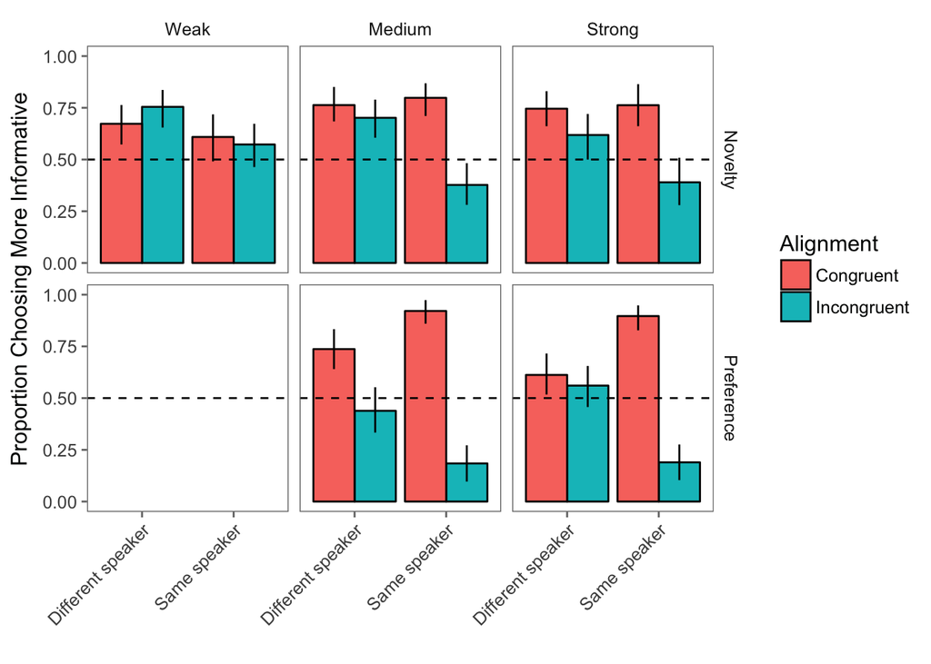

## Comparing data from Time 1 and 2

The strong prior manipulations in Time 2 are a replication of the first round of data collection. In general the results are very similar. Preference, different speaker, incongruent differs the most.

Barplot for Time 1 and 2.

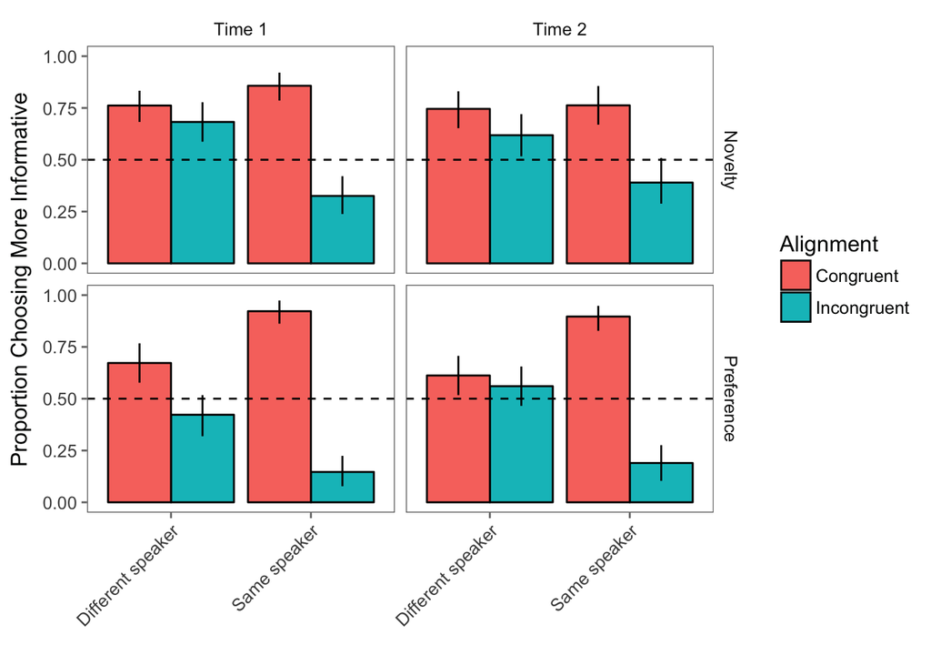

Correlation between Time 1 and 2.

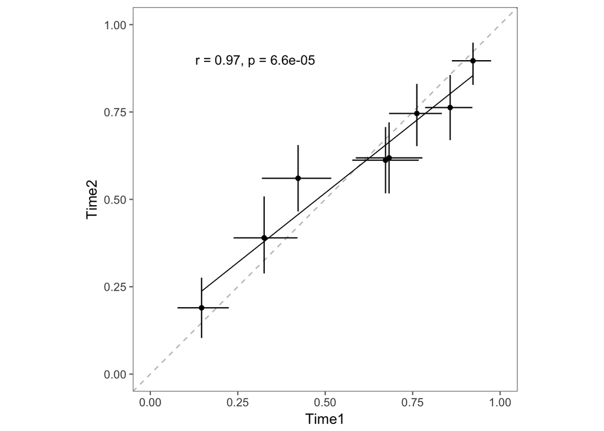

# GLMMs

Frequentist analysis: GLMMs for each level of prior strength. For “strong” and “medium” we find the interaction between speaker change and incongruent like in the first round of data collection. This suggests that participants differentiate between congruent and incongruent trials when it is the same speaker. The effect is considerably weaker in “medium”. For “weak”, this interaction is gone. This pattern makes sense and suggests that the experimental manipulations work.

## GLMM strong

```
## Generalized linear mixed model fit by maximum likelihood (Laplace
##   Approximation) [glmerMod]
##  Family: binomial  ( logit )
## Formula:
## correct_inf ~ Experiment * Change * Alignment + (Change * Alignment |
##     id) + (Change + Alignment | agent)
##    Data: m.data.strong
## Control:
## glmerControl(optimizer = "bobyqa", optCtrl = list(maxfun = 2e+05))
##
##      AIC      BIC   logLik deviance df.resid
##   1016.5   1132.7   -484.3    968.5      912
##
## Scaled residuals:
##      Min       1Q   Median       3Q      Max
## -2.07813 -0.07731  0.01687  0.46583  1.77696
##
## Random effects:
##  Groups Name                                    Variance  Std.Dev. Corr
##  id     (Intercept)                             1.335e+00  1.15525
##         ChangeSame speaker                      8.967e+01  9.46966  0.05
##         AlignmentIncongruent                    5.697e+00  2.38681 -0.87
##         ChangeSame speaker:AlignmentIncongruent 2.176e+02 14.75013  0.06
##  agent  (Intercept)                             1.029e-02  0.10142
##         ChangeSame speaker                      1.100e+00  1.04874  1.00
##         AlignmentIncongruent                    1.247e-03  0.03531 -1.00
##
##
##
##  -0.04
##  -0.74 -0.02
##
##
##  -1.00
## Number of obs: 936, groups:  id, 117; agent, 12
##
## Fixed effects:
##                                                              Estimate
## (Intercept)                                                    1.3758
## ExperimentPreference                                          -0.7726
```

[output cut: 30 more lines]

```
## ExperimentPreference:AlignmentIncongruent                    0.526728
## ChangeSame speaker:AlignmentIncongruent                      0.000104 ***
## ExperimentPreference:ChangeSame speaker:AlignmentIncongruent 0.128826
## ---
## Signif. codes:  0 '***' 0.001 '**' 0.01 '*' 0.05 '.' 0.1 ' ' 1
##
## Correlation of Fixed Effects:
##             (Intr) ExprmP ChngSs AlgnmI ExP:CSs ExP:AI CSs:AI
## ExprmntPrfr -0.720
## ChangSmspkr -0.107  0.097
## AlgnmntIncn -0.773  0.572  0.062
## ExprmnP:CSs  0.111 -0.144 -0.411 -0.060
## ExprmntP:AI  0.527 -0.758 -0.048 -0.711  0.073
## ChngSspk:AI  0.100 -0.065 -0.646 -0.072  0.268   0.051
## ExpP:CSs:AI -0.107  0.140  0.350  0.094 -0.682  -0.138 -0.649
```

## GLMM medium

```
## Generalized linear mixed model fit by maximum likelihood (Laplace
##   Approximation) [glmerMod]
##  Family: binomial  ( logit )
## Formula:
## correct_inf ~ Experiment * Change * Alignment + (Change * Alignment |
##     id) + (Change + Alignment | agent)
##    Data: m.data.medium
## Control:
## glmerControl(optimizer = "bobyqa", optCtrl = list(maxfun = 2e+05))
##
##      AIC      BIC   logLik deviance df.resid
##    976.0   1091.6   -464.0    928.0      888
##
## Scaled residuals:
##     Min      1Q  Median      3Q     Max
## -2.5216 -0.4515  0.1909  0.3998  2.0880
##
## Random effects:
##  Groups Name                                    Variance Std.Dev. Corr
##  id     (Intercept)                              3.17932 1.78307
##         ChangeSame speaker                       5.74306 2.39647  -0.53
##         AlignmentIncongruent                     7.84145 2.80026  -0.92
##         ChangeSame speaker:AlignmentIncongruent 18.12275 4.25708   0.58
##  agent  (Intercept)                              0.01106 0.10517
##         ChangeSame speaker                       0.00665 0.08155  -1.00
##         AlignmentIncongruent                     0.03043 0.17443  -1.00
##
##
##
##   0.61
##  -0.99 -0.60
##
##
##   1.00
## Number of obs: 912, groups:  id, 114; agent, 12
##
## Fixed effects:
##                                                              Estimate
## (Intercept)                                                    1.7825
## ExperimentPreference                                          -0.1040
```

[output cut: 30 more lines]

```
## ExperimentPreference:AlignmentIncongruent                      0.0664 .
## ChangeSame speaker:AlignmentIncongruent                        0.0106 *
## ExperimentPreference:ChangeSame speaker:AlignmentIncongruent   0.1115
## ---
## Signif. codes:  0 '***' 0.001 '**' 0.01 '*' 0.05 '.' 0.1 ' ' 1
##
## Correlation of Fixed Effects:
##             (Intr) ExprmP ChngSs AlgnmI ExP:CSs ExP:AI CSs:AI
## ExprmntPrfr -0.563
## ChangSmspkr -0.552  0.278
## AlgnmntIncn -0.848  0.499  0.475
## ExprmnP:CSs  0.282 -0.519 -0.177 -0.277
## ExprmntP:AI  0.470 -0.818 -0.241 -0.644  0.462
## ChngSspk:AI  0.526 -0.293 -0.882 -0.589  0.237   0.364
## ExpP:CSs:AI -0.264  0.468  0.209  0.364 -0.835  -0.569 -0.370
```

## GLMM weak (novelty only)

```
## Generalized linear mixed model fit by maximum likelihood (Laplace
##   Approximation) [glmerMod]
##  Family: binomial  ( logit )
## Formula: correct_inf ~ Change * Alignment + (Change * Alignment | id) +
##     (Change + Alignment | agent)
##    Data: m.data.weak
## Control:
## glmerControl(optimizer = "bobyqa", optCtrl = list(maxfun = 2e+05))
##
##      AIC      BIC   logLik deviance df.resid
##    557.4    639.1   -258.7    517.4      420
##
## Scaled residuals:
##     Min      1Q  Median      3Q     Max
## -1.9560 -0.5790  0.3196  0.5360  1.3118
##
## Random effects:
##  Groups Name                                    Variance Std.Dev. Corr
##  id     (Intercept)                             1.4266   1.1944
##         ChangeSame speaker                      2.7205   1.6494    0.27
##         AlignmentIncongruent                    4.1437   2.0356   -0.03
##         ChangeSame speaker:AlignmentIncongruent 7.2661   2.6956   -0.76
##  agent  (Intercept)                             0.1275   0.3571
##         ChangeSame speaker                      0.1181   0.3437   -1.00
##         AlignmentIncongruent                    0.1326   0.3642    1.00
##
##
##
##  -0.10
##  -0.79 -0.17
##
##
##  -1.00
## Number of obs: 440, groups:  id, 55; agent, 12
##
## Fixed effects:
##                                         Estimate Std. Error z value
## (Intercept)                               0.9696     0.3431   2.826
## ChangeSame speaker                       -0.1182     0.5307  -0.223
## AlignmentIncongruent                      1.1064     0.7722   1.433
## ChangeSame speaker:AlignmentIncongruent  -1.5828     0.9042  -1.751
##                                         Pr(>|z|)
## (Intercept)                              0.00471 **
## ChangeSame speaker                       0.82369
## AlignmentIncongruent                     0.15191
## ChangeSame speaker:AlignmentIncongruent  0.08002 .
## ---
## Signif. codes:  0 '***' 0.001 '**' 0.01 '*' 0.05 '.' 0.1 ' ' 1
##
## Correlation of Fixed Effects:
##             (Intr) ChngSs AlgnmI
## ChangSmspkr -0.433
## AlgnmntIncn -0.276  0.115
## ChngSspk:AI  0.114 -0.564 -0.733
```

# Comparing data to model predictions

Plots for models and predictions. I did not plot the no prior model because it predicts the same for all conditions. The predictions are the ones we pre-registered. The noise parameter is therefore estimated based on the data from the first round.

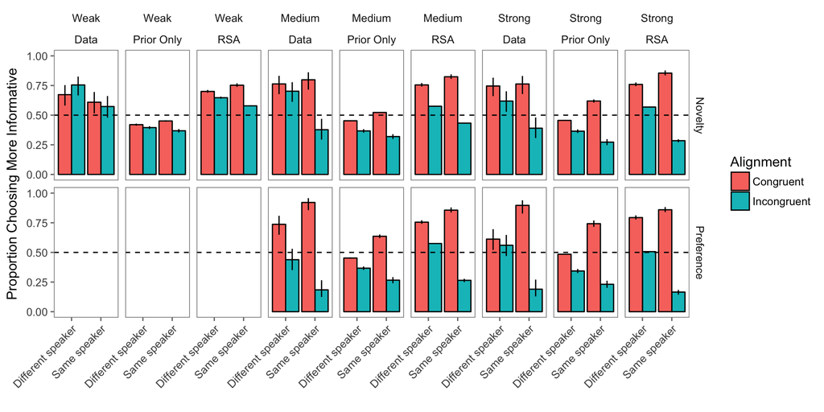

## Correlation between predictions and data

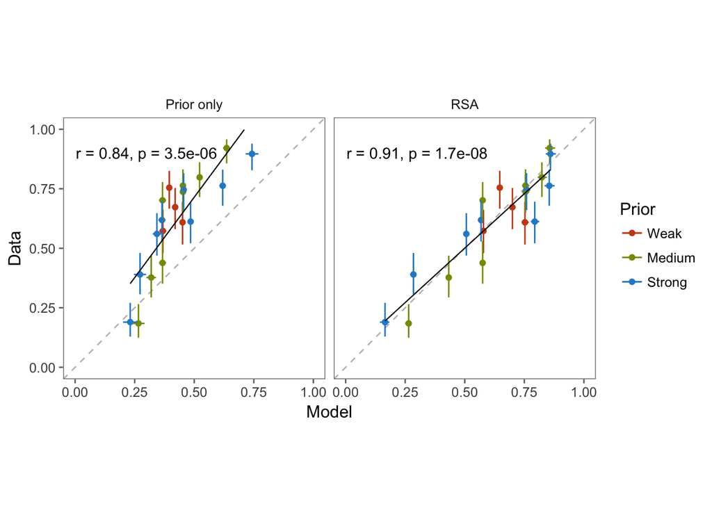

## Correlation between predictions and data seperate for each level of prior strengths

Correlation for weak prior is low because the conditions are so close to one another (see also GLMM).

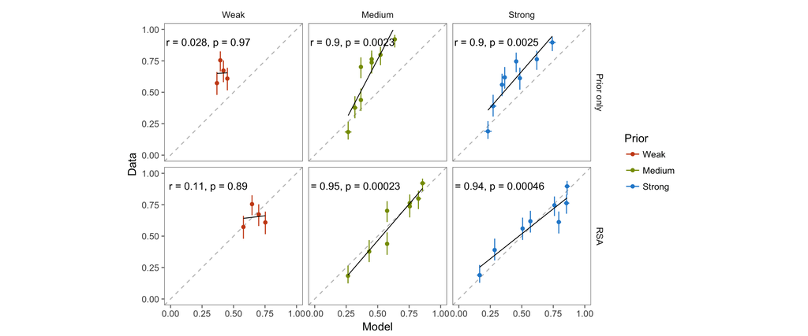

# BDA

All models, including the no prior model, comprise a noise parameter. Surprisingly, the no prior model does better than the prior only model here. This was not the case in the previous round with only the strong priors.

## Comparing models

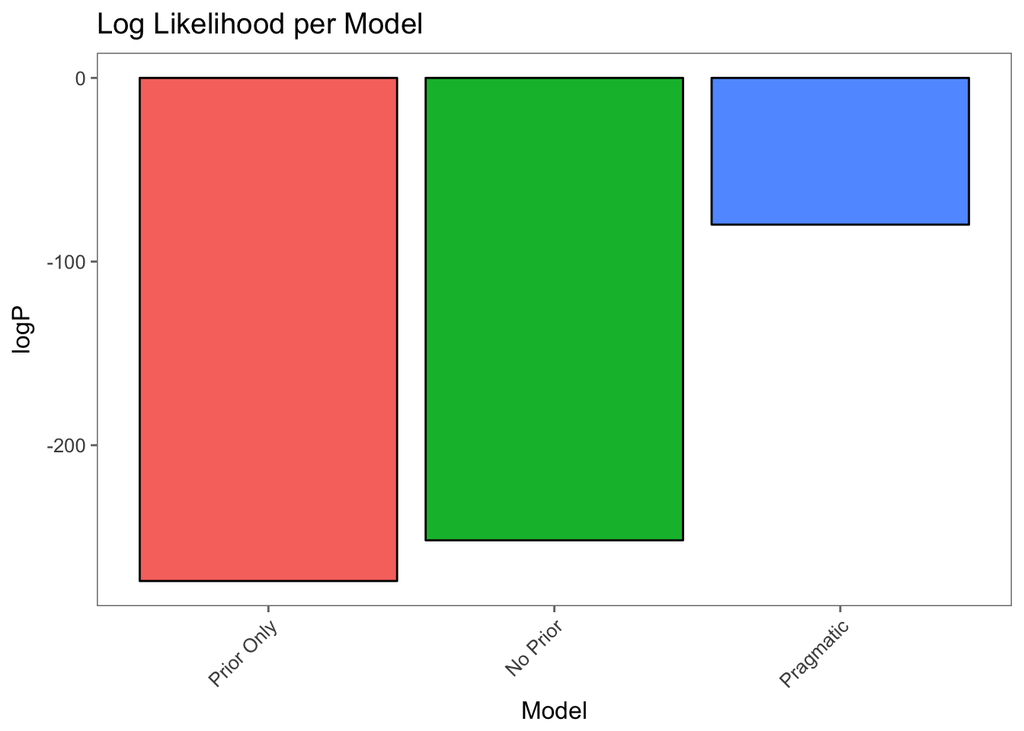

## Bayes Factors

| Comparison | BayesFactor |
| --- | --- |
| Pragmatic vs. Prior only | 1.879125e+84 |
| Pragmatic vs. No prior | 4.485236e+74 |
| No Prior vs. Prior only | 4.189579e+09 |

## Model comparison by level of prior strength

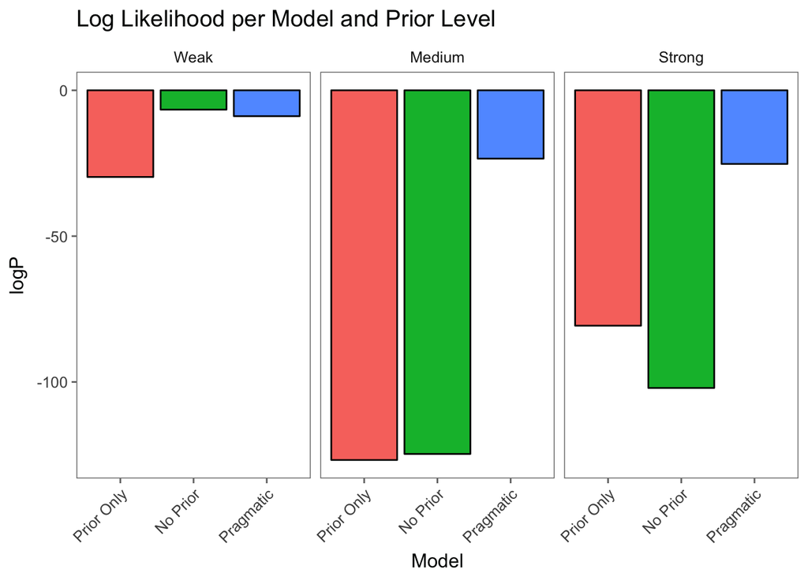

Interestingly the No Prior model does better than the RSA model with weak priors, although the difference is not huge (BF = 9.47).